# Complex Function Week 3

## Peter Ma | Aug 15

This is the homework assignment for the problem set 1.13. I had drawn the answers and then decided to code them into a jupyter notebook since I'm pretty familiar with programing :)

### **Problem 1.13**

Draw nice pictures and write a sentence or two explaining the effect of the squaring function $s(z) = z^2$ on the following regions in the complex plane:

**(a)**: the unit square in the 1st quadrant, with corners $0; 1; 1 + i$, and $i$

**(b)**: the unit square in the 3rd quadrant, with corners $0;-1;(-1-i)$, and $-i$

**(c)**: the left half plane, defined by $Re(z) < 0$

**(d)**: the exterior of the circle of radius $\frac{1}{2}$

**(e)**: the vertical line $x = a$

**(f)**: the horizontal line $y = b$

**(g)**: the line $x = y$

## Graphing Function

Here I just imported and created a function using matplotlib to help me graph these complex values generated by a complex function. Nothing fancy just some graphical changes.

```python
%matplotlib inline
import math
import matplotlib.pyplot as plt
import numpy as np

def plot_complex_number(z,x_min,x_max,y_min,y_max, dot_size=10):
    fig = plt.figure()
    fig.set_size_inches(18.5, 10.5)
    ax = plt.gca()

    ax.spines['left'].set_position('zero')
    ax.spines['right'].set_color('none')
    ax.spines['bottom'].set_position('zero')
    ax.spines['top'].set_color('none')

    b = [z.real,z.imag]

    ax = plt.axes()

    plt.scatter(a[0],a[1],color='red',s=dot_size)
    plt.scatter(b[0],b[1],color='red',s=dot_size)

    plt.axis('square')

    ax.text(0, y_max+0.5, r'Img', fontsize=10, horizontalalignment='center')
    ax.text(x_max+0.5, 0, r'Real', fontsize=10, verticalalignment='center')

    plt.xlim(x_min,x_max)
    plt.ylim(y_min,y_max)

    plt.grid(True,linestyle='--')

    plt.show()
```

# Part A

Graph the unit square in the 1st quadrant, with corners $0; 1; 1 + i$, and $i$ then apply the squaring function.

$$s(z)=z^2$$

We can first plot the corners of the square.

Rationale: When Input just the line $x=0$ we get a flat line in the real numbers since there is no imaginary componet.

We also know that $$s(z)=(x+yi)^2$$ $$s(z)=(x^2+2xyi-y^2)$$ $$s(z)=(x^2-y^2)+2xyi$$

We when we hold $y$ constant we should get the reflected parabola from above since it would have a negative of its original parabolic nature.

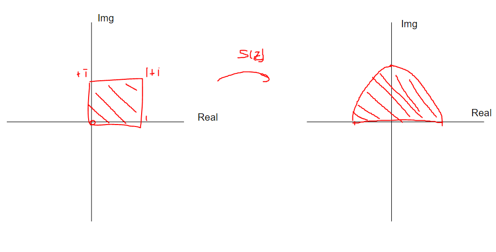

```python
from IPython.display import Image
Image('/content/a_question.PNG')
```

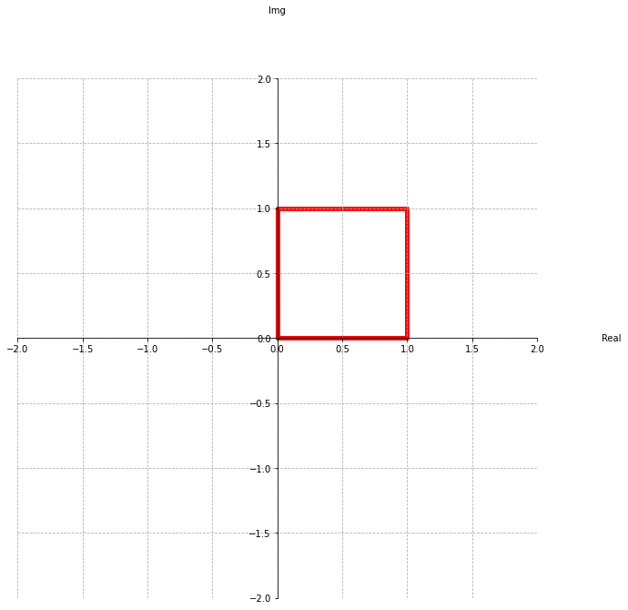

```python
min = 0
max = 1
dx = 1000
def get_input_sqaure(min, max, dx=dx):
  a = np.zeros(((max-min)*dx*4), dtype=complex)
  for i in range(int(a.shape[0]/4)):

    x_val = i/dx+min
    # Imaginary part is always zero
    y_val = 0

    complex_number = x_val + 1j*y_val

    a[i] = complex_number
  for i in range(int(a.shape[0]/4),int(a.shape[0]/2)):
    x_val = 0
    # Imaginary part is always zero
    y_val = (i-int(a.shape[0]/4))/dx+min
    complex_number = x_val + 1j*y_val
    a[i] = complex_number
  for i in range(int(a.shape[0]/2),int(a.shape[0]/2)+int(a.shape[0]/4)):
    x_val = (i-(int(a.shape[0]/2)))/dx+min
    # Imaginary part is always zero
    y_val = 1
    complex_number = x_val + 1j*y_val
    a[i] = complex_number
  for i in range(int(a.shape[0]/2)+int(a.shape[0]/4),a.shape[0]):
    x_val = 1
    y_val = (i-(int(a.shape[0]/2)+int(a.shape[0]/4)))/dx+min
    complex_number = x_val + 1j*y_val

    a[i] = complex_number
  return a

a = get_input_sqaure(min, max, dx=dx)


plot_complex_number(a, -2, 2, -2, 2)
```

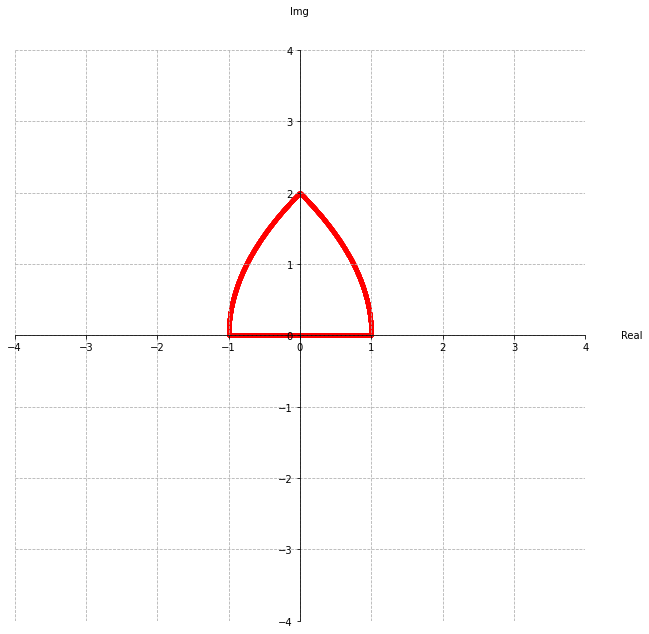

```python
def get_output_function(a):
  b = np.zeros(a.shape, dtype=complex)
  for i in range(a.shape[0]):
    real_part = a[i].real
    imag_part = a[i].imag
    # Here I wrote the function from the previous description above
    b[i] = (real_part+1j*imag_part)**2
  return b
b = get_output_function(get_input_sqaure(min, max, dx=dx))
plot_complex_number(b, -4, 4, -4, 4)
```

# Part B

$$s(z)=z^2$$

I first drew the picture. We know that this should appear the same as the first graph. This is because we can factor out a $-1$ from all the values in that quadrant and get the same result.

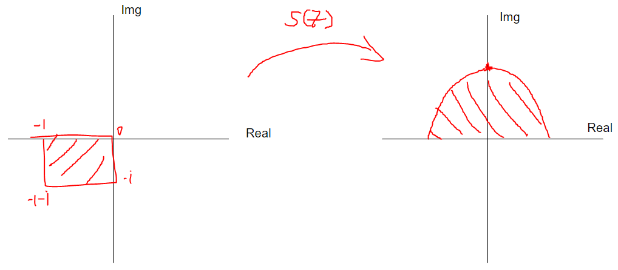

```python
from IPython.display import Image
Image('/content/b_question.PNG')
```

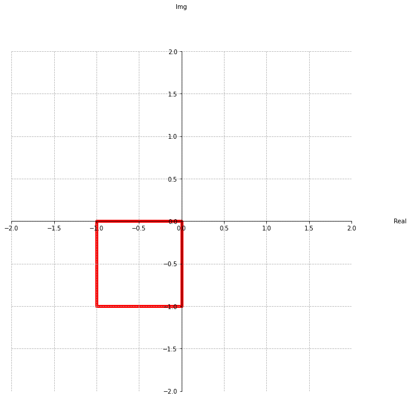

```python
min = -1
max = 0
dx = 1000
def get_input_sqaure_2(min, max, dx=dx):
  a = np.zeros(((max-min)*dx*4), dtype=complex)
  for i in range(int(a.shape[0]/4)):
    x_val = i/dx+min
    y_val = 0
    complex_number = x_val + 1j*y_val
    a[i] = complex_number
  for i in range(int(a.shape[0]/4),int(a.shape[0]/2)):
    x_val = 0
    y_val = (i-int(a.shape[0]/4))/dx+min
    complex_number = x_val + 1j*y_val
    a[i] = complex_number
  for i in range(int(a.shape[0]/2),int(a.shape[0]/2)+int(a.shape[0]/4)):
    x_val = (i-(int(a.shape[0]/2)))/dx+min
    # Imaginary part is always zero
    y_val = -1
    complex_number = x_val + 1j*y_val
    a[i] = complex_number
  for i in range(int(a.shape[0]/2)+int(a.shape[0]/4),a.shape[0]):
    x_val = -1
    y_val = (i-(int(a.shape[0]/2)+int(a.shape[0]/4)))/dx+min
    complex_number = x_val + 1j*y_val

    a[i] = complex_number
  return a
a = get_input_sqaure_2(min, max, dx=dx)
plot_complex_number(a, -2, 2, -2, 2)
```

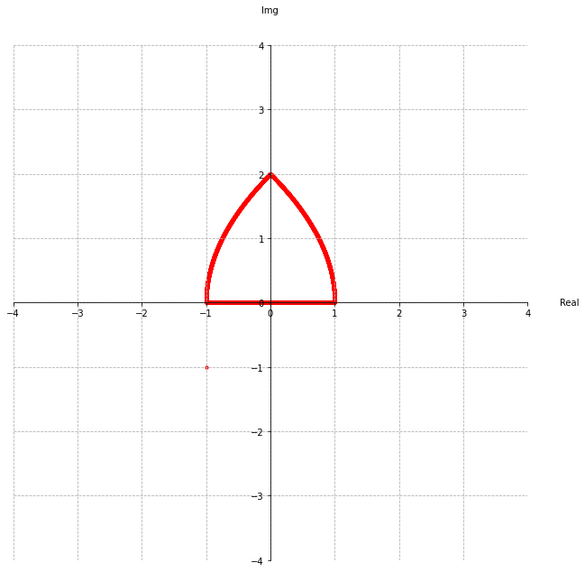

```python
def get_output_function(a):
  b = np.zeros(a.shape, dtype=complex)
  for i in range(a.shape[0]):
    real_part = a[i].real
    imag_part = a[i].imag
    # Here I wrote the function from the previous description above
    b[i] = (real_part+1j*imag_part)**2
  return b
b = get_output_function(get_input_sqaure_2(min, max, dx=dx))
plot_complex_number(b, -4, 4, -4, 4)
```

# Part C

Graph the left half plane, defined by $Re(z) < 0$ then apply the squaring function.

$$s(z)=z^2$$

I frist drew the graph with the following rationale. $$x\in (-\infty, 0)$$ $$s(z)=z^2$$ $$s(z)=(x+yi)^2$$ $$s(z)=(x^2+2xyi-y^2)$$ $$s(z)=(x^2-y^2)+2xyi$$ Notice that the real component can take on any positive value or negative value.

The Imaginary component can take on any value as well. Thus we can conclude that $s(z)$ can span the entire plane. **HOWEVER** the strip a $x=0$ should be empty as the restirctions were $x<0$.

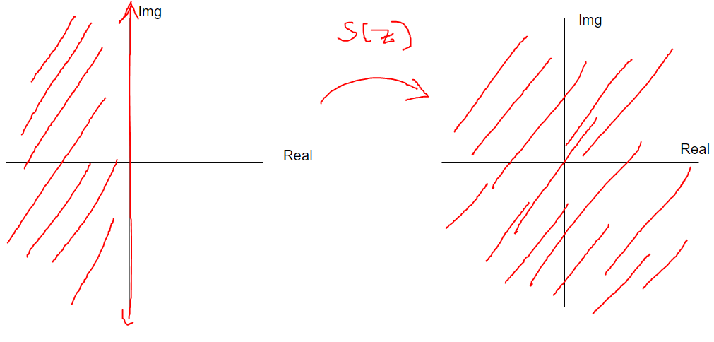

```python
from IPython.display import Image
Image('/content/c_question.PNG')
```

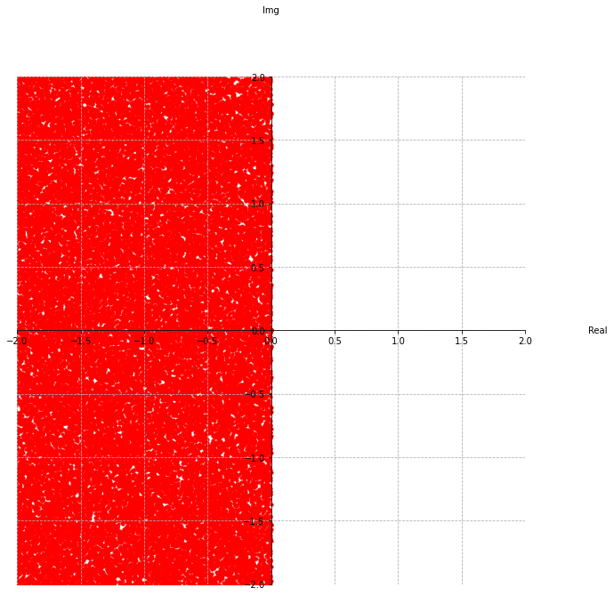

```python
import random
min = -10
max = 0
dx = 1000
def get_input_left_plane(min, max, dx=dx):
  a = np.zeros(((max-min)*dx*4), dtype=complex)
  for i in range(int(a.shape[0]/4)):
    x_val = random.random()*10+min
    y_val = random.random()*20+min
    complex_number = x_val + 1j*y_val
    a[i] = complex_number
  return a
a = get_input_left_plane(min, max, dx=100000)
plot_complex_number(a, -2, 2, -2, 2)
```

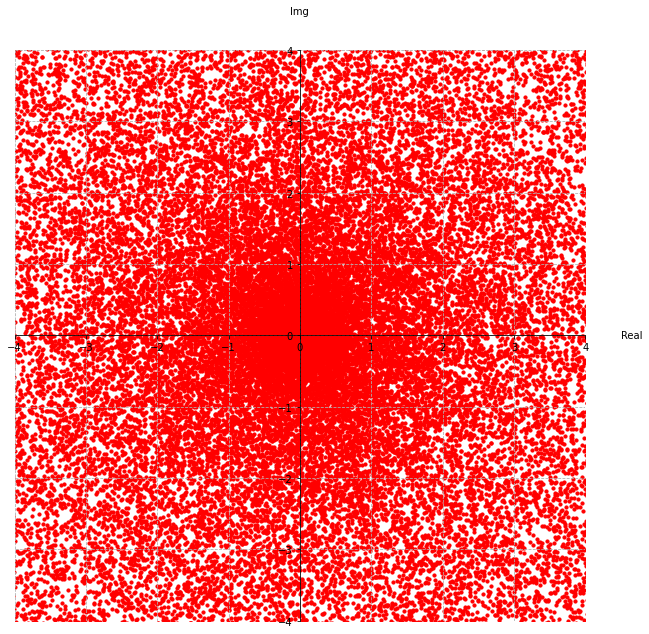

```python
def get_output_function(a):
  b = np.zeros(a.shape, dtype=complex)
  for i in range(a.shape[0]):
    real_part = a[i].real
    imag_part = a[i].imag
    # Here I wrote the function from the previous description above
    b[i] = (real_part+1j*imag_part)**2
  return b
min = -10
max = 0
dx = 1000
b = get_output_function(get_input_left_plane(min, max, dx=100000))
plot_complex_number(b, -4, 4, -4, 4)
```

# Part D

Graph the exterior of the circle of radius $\frac{1}{2}$ then apply the squaring function.

$$s(z)=z^2$$

I first drew the graph below. Here's how I came to this conclusion. We remember that when we took $w,u \in \mathbb{C} $ and performed $w \cdot u$ we got the resultant value that has a terminal arm with an angle thats the sum of $u,w$ angle with a magnitude of $|w||u|$.

Thus if we were to preform $z^2$ we should get double its angle. We should get a magnitude of $|z|^2$ in this case, since its a full circle, any added rotation gives us the original graph before the translation.

We also know we need to square its radius thus giving a radius of $\frac{1}{4}$. This gives rise to the graph below.

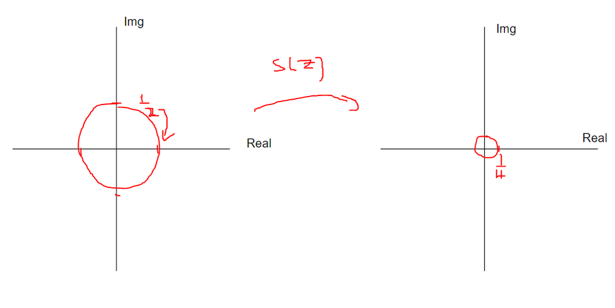

```python
from IPython.display import Image
Image('/content/d_question.PNG')
```

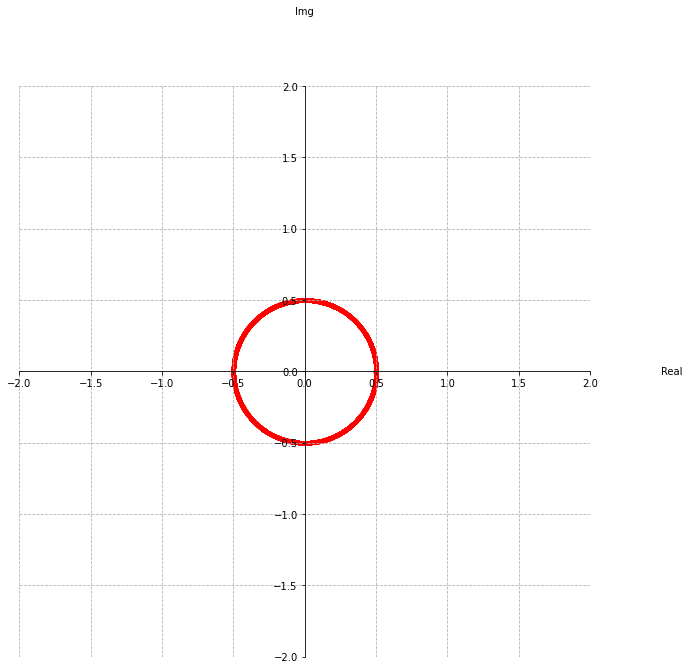

```python
import math
min = -1
max = 0
dx = 1000
def get_input_circle(radius=1/2, dx=dx):
  a = np.zeros(((max-min)*dx*4), dtype=complex)
  for i in range(a.shape[0]):
    complex_number = radius*math.e**(1j*random.random()*math.pi*2)
    a[i] = complex_number
  return a
a = get_input_circle()
plot_complex_number(a, -2, 2, -2, 2)
```

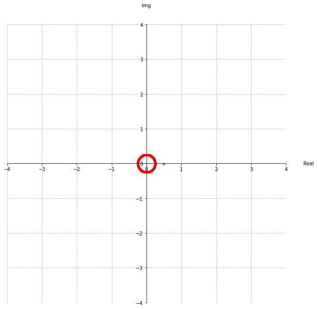

```python
def get_output_function(a):
  b = np.zeros(a.shape, dtype=complex)
  for i in range(a.shape[0]):
    real_part = a[i].real
    imag_part = a[i].imag
    # Here I wrote the function from the previous description above
    b[i] = (real_part+1j*imag_part)**2
  return b

b = get_output_function(get_input_circle())
plot_complex_number(b, -4, 4, -4, 4)
```

# Part E

Graph the exterior of the circle of radius $x=a$ then apply the squaring function.

$$s(z)=z^2$$

Below is my first drawings of the graph. I got this graph after I simplified the origianl expression with its conditions. $$s(z)=(x+yi)^2$$ $$s(z)=(a+yi)^2$$ $$s(z)=(a^2+2ayi-y^2)$$ $$s(z)=(a^2-y^2)+2ayi$$ **Rationale**: Notice that the real part $a^2-y^2$ varies quadratically as $a$ is a constant. It is also a quadratic with a negative leading coefficent. The imaginary component Varies linearly. Thus it makes sense that the graph should look parabolic opening towards the negative real numbers. The linear imaginary component stretches it out and showing the parabolic nature of the graph instead of being hiden in the real domain.

**NOTE** For the case below we've set $a=2$ for simplicity.

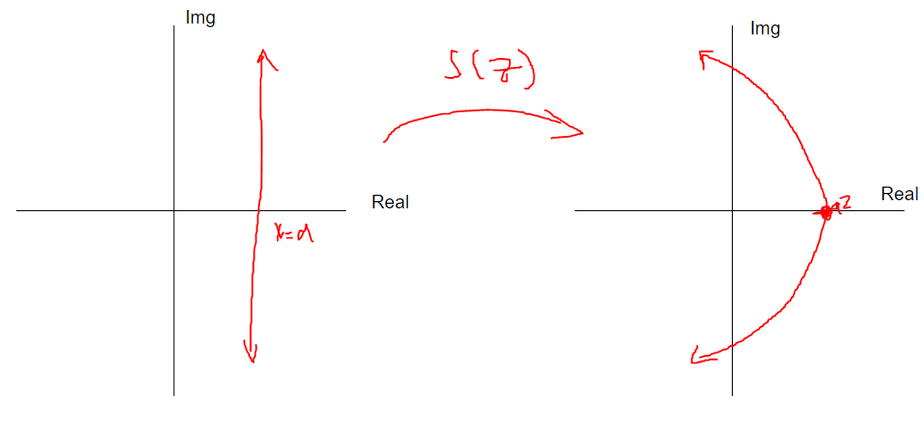

```python
from IPython.display import Image
Image('/content/e_question.PNG')
```

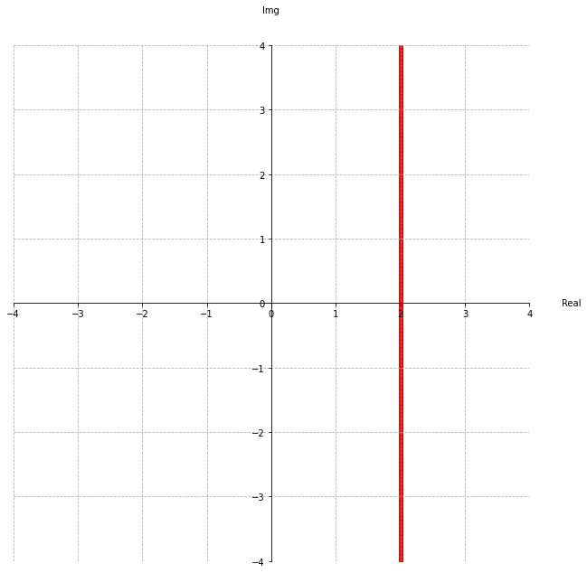

```python
min = -5
max = 1
dx = 1000
def get_input_vertical_line(min, max, dx=dx):
  a = np.zeros(((max-min)*dx*4), dtype=complex)
  for i in range(int(a.shape[0])):
    x_val = 2
    y_val = i/dx+min
    complex_number = x_val + 1j*y_val
    a[i] = complex_number
  return a

a = get_input_vertical_line(min, max, dx=dx)


plot_complex_number(a, -4, 4, -4, 4)
```

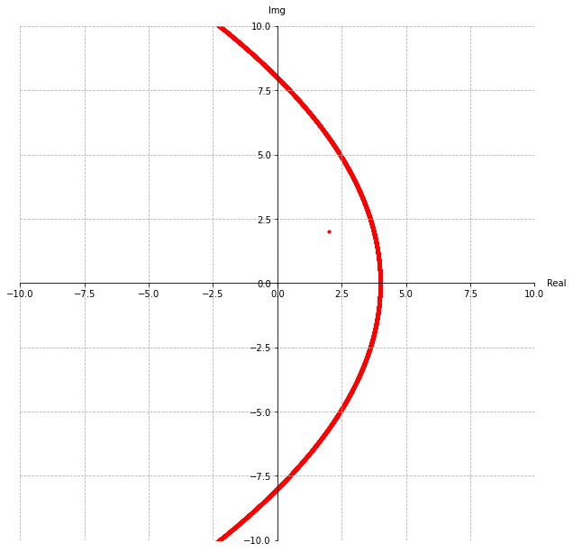

```python
def get_output_function(a):
  b = np.zeros(a.shape, dtype=complex)
  for i in range(a.shape[0]):
    real_part = a[i].real
    imag_part = a[i].imag
    # Here I wrote the function from the previous description above
    b[i] = (real_part+1j*imag_part)**2
  return b

b = get_output_function(get_input_vertical_line(min, max))
plot_complex_number(b, -10, 10, -10, 10)
```

# Part F

Graph the exterior of the circle of radius $y=a$ then apply the squaring function.

$$s(z)=z^2$$

Below is my first drawings of the graph. I got this graph after I simplified the origianl expression with its conditions. $$s(z)=(x+yi)^2$$ $$s(z)=(x+ai)^2$$ $$s(z)=(x^2+2xai-a^2)$$ $$s(z)=(x^2-a^2)+2xai$$ **Rationale**: Notice that the real part $x^2-a^2$ varies quadratically as $a$ is a constant. It is also a quadratic with a positive leading coefficent. The imaginary component Varies linearly. Thus it makes sense that the graph should look parabolic opening towards the positive real numbers. The linear imaginary component stretches it out and showing the parabolic nature of the graph instead of being 'hiden' in the real domain.

**NOTE** For the case below we've set $a=2$ for simplicity.

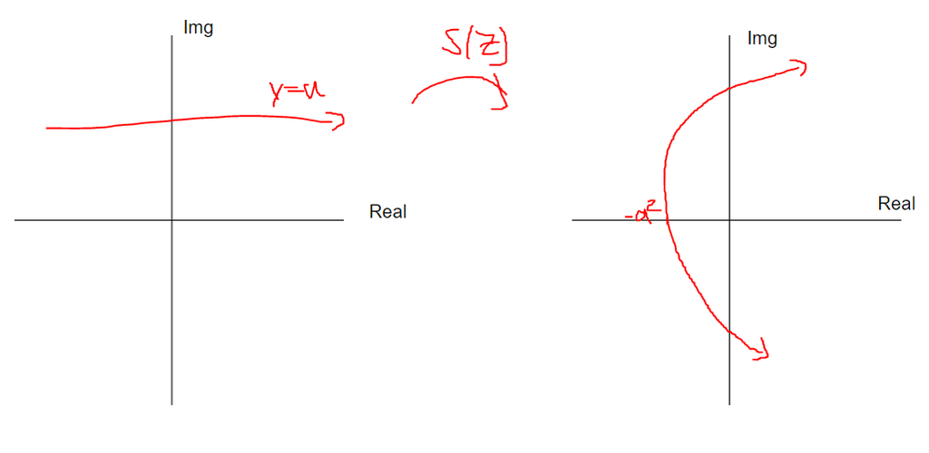

```python
from IPython.display import Image
Image('/content/f_question.PNG')
```

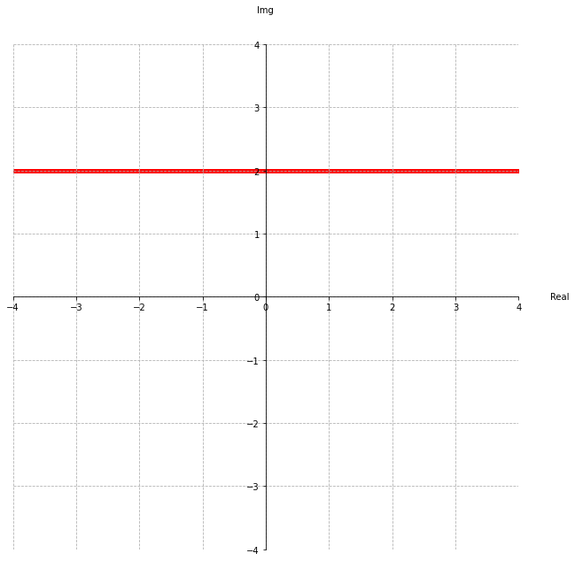

```python
min = -5
max = 1
dx = 1000
def get_input_horizontal_line(min, max, dx=dx):
  a = np.zeros(((max-min)*dx*4), dtype=complex)
  for i in range(int(a.shape[0])):
    x_val = i/dx+min
    y_val = 2
    complex_number = x_val + 1j*y_val
    a[i] = complex_number
  return a

a = get_input_horizontal_line(min, max, dx=dx)


plot_complex_number(a, -4, 4, -4, 4)
```

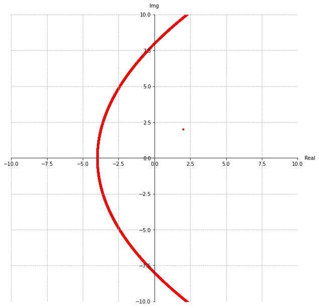

```python
def get_output_function(a):
  b = np.zeros(a.shape, dtype=complex)
  for i in range(a.shape[0]):
    real_part = a[i].real
    imag_part = a[i].imag
    # Here I wrote the function from the previous description above
    b[i] = (real_part+1j*imag_part)**2
  return b

b = get_output_function(get_input_horizontal_line(min, max))
plot_complex_number(b, -10, 10, -10, 10)
```

# Part G

Graph the exterior of the circle of radius $x=y$ then apply the squaring function.

$$s(z)=z^2$$

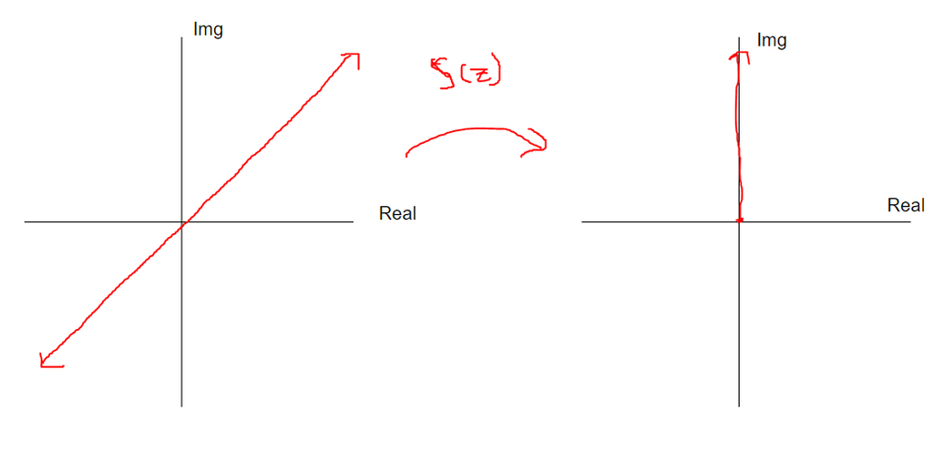

```python
from IPython.display import Image
Image('/content/g_question.PNG')
```

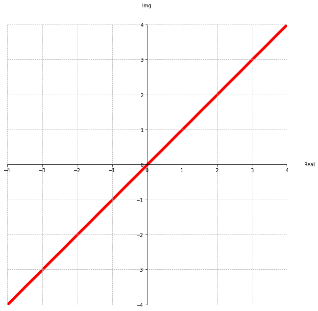

```python
min = -5
max = 1
dx = 1000
def get_input_YX(min, max, dx=dx):
  a = np.zeros(((max-min)*dx*4), dtype=complex)
  for i in range(int(a.shape[0])):
    x_val = i/dx+min
    y_val = x_val
    complex_number = x_val + 1j*y_val
    a[i] = complex_number
  return a

a = get_input_YX(min, max, dx=dx)


plot_complex_number(a, -4, 4, -4, 4)
```

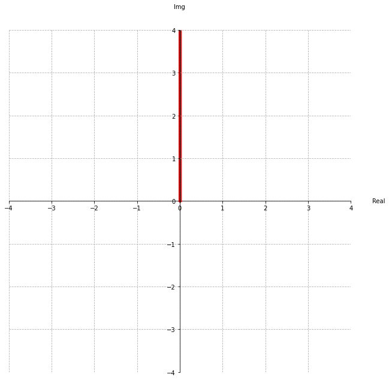

```python
def get_output_function(a):
  b = np.zeros(a.shape, dtype=complex)
  for i in range(a.shape[0]):
    real_part = a[i].real
    imag_part = a[i].imag
    # Here I wrote the function from the previous description above
    b[i] = (real_part+1j*imag_part)**2
  return b

b = get_output_function(get_input_YX(min, max, dx=dx))
plot_complex_number(b, -4, 4, -4, 4)
```